# Risk Factor Analysis

## Outcome Variable

**Outcome Variable:** stunted

## Predictor Variables

**Intervention Variable:** enstunt

**Adjustment Set:**

unadjusted

## Stratifying Variables

The analysis was stratified on these variable(s):

- agecat
- studyid

The following strata were considered:

- agecat: 12 months, studyid: ki0047075b-MAL-ED
- agecat: 12 months, studyid: ki1000108-CMC-V-BCS-2002
- agecat: 12 months, studyid: ki1000108-IRC
- agecat: 12 months, studyid: ki1000109-EE
- agecat: 12 months, studyid: ki1000109-ResPak
- agecat: 12 months, studyid: ki1000304b-SAS-FoodSuppl
- agecat: 12 months, studyid: ki1017093-NIH-Birth
- agecat: 12 months, studyid: ki1017093c-NIH-Crypto
- agecat: 12 months, studyid: ki1066203-TanzaniaChild2
- agecat: 12 months, studyid: ki1101329-Keneba
- agecat: 12 months, studyid: ki1112895-Guatemala BSC
- agecat: 12 months, studyid: ki1113344-GMS-Nepal
- agecat: 12 months, studyid: ki1114097-CMIN
- agecat: 12 months, studyid: ki1114097-CONTENT
- agecat: 12 months, studyid: ki1126311-ZVITAMBO
- agecat: 12 months, studyid: ki1135781-COHORTS
- agecat: 12 months, studyid: ki1148112-LCNI-5
- agecat: 18 months, studyid: ki0047075b-MAL-ED
- agecat: 18 months, studyid: ki1000108-CMC-V-BCS-2002
- agecat: 18 months, studyid: ki1000108-IRC
- agecat: 18 months, studyid: ki1000109-EE
- agecat: 18 months, studyid: ki1000109-ResPak
- agecat: 18 months, studyid: ki1000304b-SAS-FoodSuppl
- agecat: 18 months, studyid: ki1017093-NIH-Birth
- agecat: 18 months, studyid: ki1017093c-NIH-Crypto
- agecat: 18 months, studyid: ki1066203-TanzaniaChild2
- agecat: 18 months, studyid: ki1101329-Keneba
- agecat: 18 months, studyid: ki1113344-GMS-Nepal
- agecat: 18 months, studyid: ki1114097-CMIN
- agecat: 18 months, studyid: ki1114097-CONTENT
- agecat: 18 months, studyid: ki1126311-ZVITAMBO
- agecat: 18 months, studyid: ki1135781-COHORTS
- agecat: 18 months, studyid: ki1148112-LCNI-5
- agecat: 24 months, studyid: ki0047075b-MAL-ED
- agecat: 24 months, studyid: ki1000108-CMC-V-BCS-2002
- agecat: 24 months, studyid: ki1000108-IRC
- agecat: 24 months, studyid: ki1017093-NIH-Birth
- agecat: 24 months, studyid: ki1017093c-NIH-Crypto
- agecat: 24 months, studyid: ki1101329-Keneba
- agecat: 24 months, studyid: ki1113344-GMS-Nepal
- agecat: 24 months, studyid: ki1114097-CMIN
- agecat: 24 months, studyid: ki1114097-CONTENT
- agecat: 24 months, studyid: ki1126311-ZVITAMBO
- agecat: 24 months, studyid: ki1135781-COHORTS
- agecat: 24 months, studyid: ki1148112-LCNI-5
- agecat: 3 months, studyid: ki0047075b-MAL-ED
- agecat: 3 months, studyid: ki1000108-CMC-V-BCS-2002
- agecat: 3 months, studyid: ki1000108-IRC
- agecat: 3 months, studyid: ki1000109-EE
- agecat: 3 months, studyid: ki1000109-ResPak
- agecat: 3 months, studyid: ki1000304b-SAS-FoodSuppl
- agecat: 3 months, studyid: ki1017093-NIH-Birth
- agecat: 3 months, studyid: ki1017093c-NIH-Crypto
- agecat: 3 months, studyid: ki1066203-TanzaniaChild2
- agecat: 3 months, studyid: ki1101329-Keneba
- agecat: 3 months, studyid: ki1112895-Guatemala BSC
- agecat: 3 months, studyid: ki1113344-GMS-Nepal
- agecat: 3 months, studyid: ki1114097-CMIN
- agecat: 3 months, studyid: ki1114097-CONTENT
- agecat: 3 months, studyid: ki1126311-ZVITAMBO
- agecat: 3 months, studyid: ki1135781-COHORTS
- agecat: 6 months, studyid: ki0047075b-MAL-ED
- agecat: 6 months, studyid: ki1000108-CMC-V-BCS-2002
- agecat: 6 months, studyid: ki1000108-IRC
- agecat: 6 months, studyid: ki1000109-EE
- agecat: 6 months, studyid: ki1000109-ResPak
- agecat: 6 months, studyid: ki1000304b-SAS-FoodSuppl
- agecat: 6 months, studyid: ki1017093-NIH-Birth
- agecat: 6 months, studyid: ki1017093c-NIH-Crypto
- agecat: 6 months, studyid: ki1066203-TanzaniaChild2
- agecat: 6 months, studyid: ki1101329-Keneba
- agecat: 6 months, studyid: ki1112895-Guatemala BSC
- agecat: 6 months, studyid: ki1113344-GMS-Nepal
- agecat: 6 months, studyid: ki1114097-CMIN
- agecat: 6 months, studyid: ki1114097-CONTENT
- agecat: 6 months, studyid: ki1126311-ZVITAMBO
- agecat: 6 months, studyid: ki1135781-COHORTS
- agecat: 6 months, studyid: ki1148112-LCNI-5
- agecat: 9 months, studyid: ki0047075b-MAL-ED
- agecat: 9 months, studyid: ki1000108-CMC-V-BCS-2002
- agecat: 9 months, studyid: ki1000108-IRC
- agecat: 9 months, studyid: ki1000109-EE
- agecat: 9 months, studyid: ki1000109-ResPak
- agecat: 9 months, studyid: ki1000304b-SAS-FoodSuppl
- agecat: 9 months, studyid: ki1017093-NIH-Birth
- agecat: 9 months, studyid: ki1017093c-NIH-Crypto
- agecat: 9 months, studyid: ki1066203-TanzaniaChild2
- agecat: 9 months, studyid: ki1101329-Keneba
- agecat: 9 months, studyid: ki1112895-Guatemala BSC
- agecat: 9 months, studyid: ki1113344-GMS-Nepal
- agecat: 9 months, studyid: ki1114097-CMIN
- agecat: 9 months, studyid: ki1114097-CONTENT
- agecat: 9 months, studyid: ki1126311-ZVITAMBO
- agecat: 9 months, studyid: ki1135781-COHORTS
- agecat: 9 months, studyid: ki1148112-LCNI-5
- agecat: Birth, studyid: ki0047075b-MAL-ED
- agecat: Birth, studyid: ki1000108-CMC-V-BCS-2002
- agecat: Birth, studyid: ki1000108-IRC
- agecat: Birth, studyid: ki1000109-EE
- agecat: Birth, studyid: ki1000109-ResPak
- agecat: Birth, studyid: ki1017093-NIH-Birth
- agecat: Birth, studyid: ki1017093c-NIH-Crypto
- agecat: Birth, studyid: ki1101329-Keneba
- agecat: Birth, studyid: ki1114097-CMIN
- agecat: Birth, studyid: ki1114097-CONTENT
- agecat: Birth, studyid: ki1126311-ZVITAMBO
- agecat: Birth, studyid: ki1135781-COHORTS

### Dropped Strata

Some strata were dropped due to rare outcomes:

- agecat: 12 months, studyid: ki1000109-EE
- agecat: 12 months, studyid: ki1000109-ResPak
- agecat: 12 months, studyid: ki1000304b-SAS-FoodSuppl
- agecat: 12 months, studyid: ki1017093c-NIH-Crypto
- agecat: 12 months, studyid: ki1066203-TanzaniaChild2
- agecat: 12 months, studyid: ki1112895-Guatemala BSC
- agecat: 12 months, studyid: ki1113344-GMS-Nepal
- agecat: 12 months, studyid: ki1114097-CONTENT
- agecat: 18 months, studyid: ki1000109-EE
- agecat: 18 months, studyid: ki1000109-ResPak
- agecat: 18 months, studyid: ki1000304b-SAS-FoodSuppl
- agecat: 18 months, studyid: ki1017093c-NIH-Crypto
- agecat: 18 months, studyid: ki1066203-TanzaniaChild2
- agecat: 18 months, studyid: ki1113344-GMS-Nepal
- agecat: 18 months, studyid: ki1114097-CONTENT
- agecat: 24 months, studyid: ki1017093c-NIH-Crypto
- agecat: 24 months, studyid: ki1113344-GMS-Nepal
- agecat: 24 months, studyid: ki1114097-CMIN
- agecat: 24 months, studyid: ki1114097-CONTENT
- agecat: 3 months, studyid: ki1000109-EE
- agecat: 3 months, studyid: ki1000304b-SAS-FoodSuppl
- agecat: 3 months, studyid: ki1017093c-NIH-Crypto
- agecat: 3 months, studyid: ki1066203-TanzaniaChild2
- agecat: 3 months, studyid: ki1112895-Guatemala BSC
- agecat: 3 months, studyid: ki1113344-GMS-Nepal
- agecat: 3 months, studyid: ki1114097-CONTENT
- agecat: 6 months, studyid: ki1000109-EE
- agecat: 6 months, studyid: ki1000304b-SAS-FoodSuppl
- agecat: 6 months, studyid: ki1017093c-NIH-Crypto
- agecat: 6 months, studyid: ki1066203-TanzaniaChild2
- agecat: 6 months, studyid: ki1112895-Guatemala BSC
- agecat: 6 months, studyid: ki1113344-GMS-Nepal
- agecat: 6 months, studyid: ki1114097-CONTENT
- agecat: 6 months, studyid: ki1148112-LCNI-5
- agecat: 9 months, studyid: ki1000109-EE
- agecat: 9 months, studyid: ki1000109-ResPak
- agecat: 9 months, studyid: ki1000304b-SAS-FoodSuppl
- agecat: 9 months, studyid: ki1017093c-NIH-Crypto
- agecat: 9 months, studyid: ki1066203-TanzaniaChild2
- agecat: 9 months, studyid: ki1112895-Guatemala BSC
- agecat: 9 months, studyid: ki1113344-GMS-Nepal
- agecat: 9 months, studyid: ki1114097-CONTENT
- agecat: Birth, studyid: ki0047075b-MAL-ED
- agecat: Birth, studyid: ki1000108-CMC-V-BCS-2002
- agecat: Birth, studyid: ki1000108-IRC
- agecat: Birth, studyid: ki1000109-EE
- agecat: Birth, studyid: ki1000109-ResPak
- agecat: Birth, studyid: ki1017093-NIH-Birth
- agecat: Birth, studyid: ki1017093c-NIH-Crypto
- agecat: Birth, studyid: ki1101329-Keneba
- agecat: Birth, studyid: ki1114097-CMIN
- agecat: Birth, studyid: ki1114097-CONTENT
- agecat: Birth, studyid: ki1126311-ZVITAMBO
- agecat: Birth, studyid: ki1135781-COHORTS

## Methods Detail

We’re interested in the causal parameters $E[Y_a]$ for all values of $a \in \mathcal{A}$. These parameters represent the mean outcome if, possibly contrary to fact, we intervened to set all units to have $A=a$. Under the randomization and positivity assumptions, these are identified by the statistical parameters $\psi_a=E_W[E_{Y|A,W}(Y|A=a,W)]$. In addition, we’re interested in the mean of $Y$, $E[Y]$ under no intervention (the observed mean). We will estimate these parameters by using SuperLearner to fit the relevant likelihood factors – $E_{Y|A,W}(Y|A=a,W)$ and $p(A=a|W)$, and then updating our likelihood fit using a joint TMLE.

For unadjusted analyses ($W=\{\}$), initial likelihoods were estimated using Lrnr_glm to estimate the simple $E(Y|A)$ and Lrnr_mean to estimate $p(A)$. For adjusted analyses, a small library containing Lrnr_glmnet, Lrnr_xgboost, and Lrnr_mean was used.

Having estimated these parameters, we will then use the delta method to estimate relative risks and attributable risks relative to a prespecified baseline level of $A$.

# Results Detail

## Results Plots

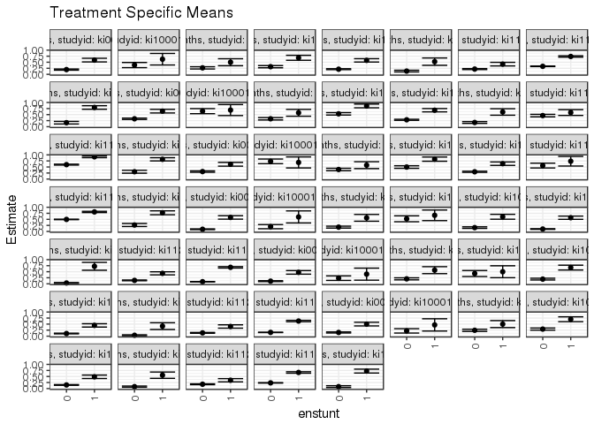

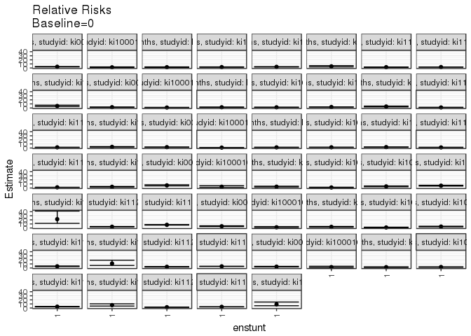

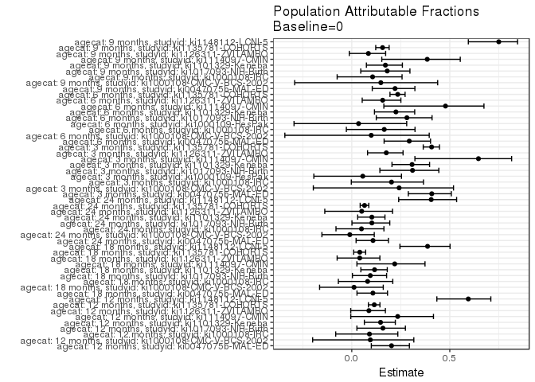

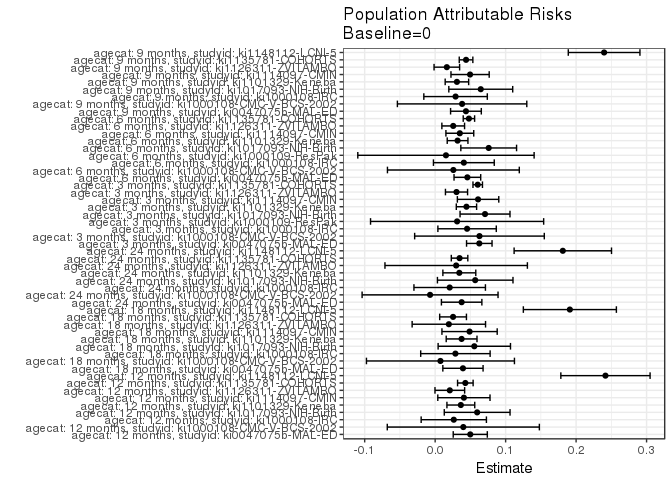

## Data Summary

| agecat | studyid | A | n | nA | nAY0 | nAY1 |
| --- | --- | --- | --- | --- | --- | --- |
| 12 months | ki0047075b-MAL-ED | 0 | 1298 | 1133 | 911 | 222 |
| 12 months | ki0047075b-MAL-ED | 1 | 1298 | 165 | 68 | 97 |
| 12 months | ki1000108-CMC-V-BCS-2002 | 0 | 97 | 81 | 50 | 31 |
| 12 months | ki1000108-CMC-V-BCS-2002 | 1 | 97 | 16 | 6 | 10 |
| 12 months | ki1000108-IRC | 0 | 406 | 360 | 264 | 96 |
| 12 months | ki1000108-IRC | 1 | 406 | 46 | 23 | 23 |
| 12 months | ki1000109-EE | 0 | 7 | 4 | 3 | 1 |
| 12 months | ki1000109-EE | 1 | 7 | 3 | 0 | 3 |
| 12 months | ki1000109-ResPak | 0 | 59 | 49 | 29 | 20 |
| 12 months | ki1000109-ResPak | 1 | 59 | 10 | 7 | 3 |
| 12 months | ki1000304b-SAS-FoodSuppl | 0 | 91 | 56 | 14 | 42 |
| 12 months | ki1000304b-SAS-FoodSuppl | 1 | 91 | 35 | 4 | 31 |
| 12 months | ki1017093-NIH-Birth | 0 | 488 | 409 | 280 | 129 |
| 12 months | ki1017093-NIH-Birth | 1 | 488 | 79 | 25 | 54 |
| 12 months | ki1017093c-NIH-Crypto | 0 | 25 | 21 | 16 | 5 |
| 12 months | ki1017093c-NIH-Crypto | 1 | 25 | 4 | 3 | 1 |
| 12 months | ki1066203-TanzaniaChild2 | 0 | 4 | 4 | 3 | 1 |
| 12 months | ki1066203-TanzaniaChild2 | 1 | 4 | 0 | 0 | 0 |
| 12 months | ki1101329-Keneba | 0 | 1947 | 1753 | 1382 | 371 |
| 12 months | ki1101329-Keneba | 1 | 1947 | 194 | 82 | 112 |
| 12 months | ki1112895-Guatemala BSC | 0 | 50 | 37 | 27 | 10 |
| 12 months | ki1112895-Guatemala BSC | 1 | 50 | 13 | 1 | 12 |
| 12 months | ki1113344-GMS-Nepal | 0 | 50 | 40 | 28 | 12 |
| 12 months | ki1113344-GMS-Nepal | 1 | 50 | 10 | 2 | 8 |
| 12 months | ki1114097-CMIN | 0 | 402 | 360 | 312 | 48 |
| 12 months | ki1114097-CMIN | 1 | 402 | 42 | 20 | 22 |
| 12 months | ki1114097-CONTENT | 0 | 55 | 49 | 42 | 7 |
| 12 months | ki1114097-CONTENT | 1 | 55 | 6 | 3 | 3 |
| 12 months | ki1126311-ZVITAMBO | 0 | 1677 | 1506 | 1179 | 327 |
| 12 months | ki1126311-ZVITAMBO | 1 | 1677 | 171 | 99 | 72 |

[output cut: 208 more lines]

## Results Table

### Parameter: TSM

| agecat | studyid | intervention_level | baseline_level | estimate | ci_lower | ci_upper |
| --- | --- | --- | --- | --- | --- | --- |
| 12 months | ki0047075b-MAL-ED | 0 | NA | 0.1959400 | 0.1728190 | 0.2190610 |
| 12 months | ki0047075b-MAL-ED | 1 | NA | 0.5878788 | 0.5127459 | 0.6630116 |
| 12 months | ki1000108-CMC-V-BCS-2002 | 0 | NA | 0.3827160 | 0.2763173 | 0.4891148 |
| 12 months | ki1000108-CMC-V-BCS-2002 | 1 | NA | 0.6250000 | 0.3865518 | 0.8634482 |
| 12 months | ki1000108-IRC | 0 | NA | 0.2666667 | 0.2209297 | 0.3124036 |
| 12 months | ki1000108-IRC | 1 | NA | 0.5000000 | 0.3553313 | 0.6446687 |
| 12 months | ki1017093-NIH-Birth | 0 | NA | 0.3154034 | 0.2703236 | 0.3604833 |
| 12 months | ki1017093-NIH-Birth | 1 | NA | 0.6835443 | 0.5808799 | 0.7862087 |
| 12 months | ki1101329-Keneba | 0 | NA | 0.2116372 | 0.1925110 | 0.2307634 |
| 12 months | ki1101329-Keneba | 1 | NA | 0.5773196 | 0.5077895 | 0.6468497 |
| 12 months | ki1114097-CMIN | 0 | NA | 0.1333333 | 0.0981746 | 0.1684921 |
| 12 months | ki1114097-CMIN | 1 | NA | 0.5238095 | 0.3725783 | 0.6750407 |
| 12 months | ki1126311-ZVITAMBO | 0 | NA | 0.2171315 | 0.1963024 | 0.2379606 |
| 12 months | ki1126311-ZVITAMBO | 1 | NA | 0.4210526 | 0.3470295 | 0.4950757 |
| 12 months | ki1135781-COHORTS | 0 | NA | 0.3304137 | 0.3197114 | 0.3411159 |
| 12 months | ki1135781-COHORTS | 1 | NA | 0.7382319 | 0.7090361 | 0.7674277 |
| 12 months | ki1148112-LCNI-5 | 0 | NA | 0.1648936 | 0.1117617 | 0.2180255 |
| 12 months | ki1148112-LCNI-5 | 1 | NA | 0.7948718 | 0.7215844 | 0.8681592 |
| 18 months | ki0047075b-MAL-ED | 0 | NA | 0.3262477 | 0.2983008 | 0.3541946 |
| 18 months | ki0047075b-MAL-ED | 1 | NA | 0.6428571 | 0.5671492 | 0.7185651 |
| 18 months | ki1000108-CMC-V-BCS-2002 | 0 | NA | 0.6419753 | 0.5370280 | 0.7469227 |
| 18 months | ki1000108-CMC-V-BCS-2002 | 1 | NA | 0.6875000 | 0.4592033 | 0.9157967 |
| 18 months | ki1000108-IRC | 0 | NA | 0.3268156 | 0.2781680 | 0.3754633 |
| 18 months | ki1000108-IRC | 1 | NA | 0.5744681 | 0.4329425 | 0.7159937 |
| 18 months | ki1017093-NIH-Birth | 0 | NA | 0.5314136 | 0.4813179 | 0.5815093 |
| 18 months | ki1017093-NIH-Birth | 1 | NA | 0.8589744 | 0.7816507 | 0.9362980 |
| 18 months | ki1101329-Keneba | 0 | NA | 0.2850575 | 0.2638403 | 0.3062747 |
| 18 months | ki1101329-Keneba | 1 | NA | 0.6813187 | 0.6136046 | 0.7490327 |
| 18 months | ki1114097-CMIN | 0 | NA | 0.1741294 | 0.1370180 | 0.2112407 |
| 18 months | ki1114097-CMIN | 1 | NA | 0.6078431 | 0.4737000 | 0.7419863 |

[output cut: 76 more lines]

### Parameter: E(Y)

| agecat | studyid | intervention_level | baseline_level | estimate | ci_lower | ci_upper |
| --- | --- | --- | --- | --- | --- | --- |
| 12 months | ki0047075b-MAL-ED | NA | NA | 0.2457627 | 0.2386575 | 0.2528679 |
| 12 months | ki1000108-CMC-V-BCS-2002 | NA | NA | 0.4226804 | 0.4046930 | 0.4406678 |
| 12 months | ki1000108-IRC | NA | NA | 0.2931034 | 0.2859006 | 0.3003063 |
| 12 months | ki1017093-NIH-Birth | NA | NA | 0.3750000 | 0.3629565 | 0.3870435 |
| 12 months | ki1101329-Keneba | NA | NA | 0.2480740 | 0.2432076 | 0.2529403 |
| 12 months | ki1114097-CMIN | NA | NA | 0.1741294 | 0.1624392 | 0.1858195 |
| 12 months | ki1126311-ZVITAMBO | NA | NA | 0.2379249 | 0.2349706 | 0.2408791 |
| 12 months | ki1135781-COHORTS | NA | NA | 0.3732513 | 0.3705598 | 0.3759428 |
| 12 months | ki1148112-LCNI-5 | NA | NA | 0.4065574 | 0.3721217 | 0.4409931 |
| 18 months | ki0047075b-MAL-ED | NA | NA | 0.3656958 | 0.3598641 | 0.3715275 |
| 18 months | ki1000108-CMC-V-BCS-2002 | NA | NA | 0.6494845 | 0.6461047 | 0.6528643 |
| 18 months | ki1000108-IRC | NA | NA | 0.3555556 | 0.3478210 | 0.3632901 |
| 18 months | ki1017093-NIH-Birth | NA | NA | 0.5869565 | 0.5757116 | 0.5982014 |
| 18 months | ki1101329-Keneba | NA | NA | 0.3225806 | 0.3173924 | 0.3277689 |
| 18 months | ki1114097-CMIN | NA | NA | 0.2229581 | 0.2103200 | 0.2355962 |
| 18 months | ki1126311-ZVITAMBO | NA | NA | 0.4785714 | 0.4742266 | 0.4829162 |
| 18 months | ki1135781-COHORTS | NA | NA | 0.6217725 | 0.6185851 | 0.6249599 |
| 18 months | ki1148112-LCNI-5 | NA | NA | 0.4943182 | 0.4683446 | 0.5202917 |
| 24 months | ki0047075b-MAL-ED | NA | NA | 0.3468354 | 0.3411463 | 0.3525246 |
| 24 months | ki1000108-CMC-V-BCS-2002 | NA | NA | 0.7244898 | 0.7212382 | 0.7277414 |
| 24 months | ki1000108-IRC | NA | NA | 0.4156479 | 0.4100950 | 0.4212008 |
| 24 months | ki1017093-NIH-Birth | NA | NA | 0.5539906 | 0.5422065 | 0.5657748 |
| 24 months | ki1101329-Keneba | NA | NA | 0.3346868 | 0.3298837 | 0.3394898 |
| 24 months | ki1126311-ZVITAMBO | NA | NA | 0.5877193 | 0.5754232 | 0.6000154 |
| 24 months | ki1135781-COHORTS | NA | NA | 0.5314419 | 0.5293217 | 0.5335621 |
| 24 months | ki1148112-LCNI-5 | NA | NA | 0.4470990 | 0.4192981 | 0.4748999 |
| 3 months | ki0047075b-MAL-ED | NA | NA | 0.1534688 | 0.1449931 | 0.1619445 |
| 3 months | ki1000108-CMC-V-BCS-2002 | NA | NA | 0.2604167 | 0.2310310 | 0.2898023 |
| 3 months | ki1000108-IRC | NA | NA | 0.2235872 | 0.2115328 | 0.2356416 |
| 3 months | ki1000109-ResPak | NA | NA | 0.5542169 | 0.5414089 | 0.5670248 |
| 3 months | ki1017093-NIH-Birth | NA | NA | 0.2283186 | 0.2148141 | 0.2418231 |
| 3 months | ki1101329-Keneba | NA | NA | 0.1443582 | 0.1386156 | 0.1501007 |
| 3 months | ki1114097-CMIN | NA | NA | 0.0942249 | 0.0730301 | 0.1154198 |
| 3 months | ki1126311-ZVITAMBO | NA | NA | 0.1721677 | 0.1684833 | 0.1758521 |
| 3 months | ki1135781-COHORTS | NA | NA | 0.1482742 | 0.1448032 | 0.1517451 |
| 6 months | ki0047075b-MAL-ED | NA | NA | 0.1558824 | 0.1494747 | 0.1622900 |
| 6 months | ki1000108-CMC-V-BCS-2002 | NA | NA | 0.2604167 | 0.2483379 | 0.2724954 |
| 6 months | ki1000108-IRC | NA | NA | 0.2457002 | 0.2346058 | 0.2567947 |
| 6 months | ki1000109-ResPak | NA | NA | 0.4415584 | 0.4348293 | 0.4482876 |
| 6 months | ki1017093-NIH-Birth | NA | NA | 0.2701689 | 0.2553478 | 0.2849899 |
| 6 months | ki1101329-Keneba | NA | NA | 0.1412835 | 0.1370542 | 0.1455128 |
| 6 months | ki1114097-CMIN | NA | NA | 0.0732177 | 0.0637759 | 0.0826595 |
| 6 months | ki1126311-ZVITAMBO | NA | NA | 0.1625616 | 0.1591601 | 0.1659630 |
| 6 months | ki1135781-COHORTS | NA | NA | 0.2043721 | 0.2015605 | 0.2071838 |
| 9 months | ki0047075b-MAL-ED | NA | NA | 0.1978691 | 0.1916548 | 0.2040834 |
| 9 months | ki1000108-CMC-V-BCS-2002 | NA | NA | 0.2577320 | 0.2398563 | 0.2756076 |
| 9 months | ki1000108-IRC | NA | NA | 0.2727273 | 0.2648358 | 0.2806187 |
| 9 months | ki1017093-NIH-Birth | NA | NA | 0.3578529 | 0.3448367 | 0.3708691 |
| 9 months | ki1101329-Keneba | NA | NA | 0.1800581 | 0.1758603 | 0.1842559 |
| 9 months | ki1114097-CMIN | NA | NA | 0.1287313 | 0.1164352 | 0.1410275 |
| 9 months | ki1126311-ZVITAMBO | NA | NA | 0.1954616 | 0.1932564 | 0.1976668 |
| 9 months | ki1135781-COHORTS | NA | NA | 0.2790412 | 0.2763459 | 0.2817366 |
| 9 months | ki1148112-LCNI-5 | NA | NA | 0.3197492 | 0.2855880 | 0.3539104 |

### Parameter: RR

| agecat | studyid | intervention_level | baseline_level | estimate | ci_lower | ci_upper |
| --- | --- | --- | --- | --- | --- | --- |
| 12 months | ki0047075b-MAL-ED | 1 | 0 | 3.0003003 | 2.5212752 | 3.570337 |
| 12 months | ki1000108-CMC-V-BCS-2002 | 1 | 0 | 1.6330645 | 1.0185643 | 2.618293 |
| 12 months | ki1000108-IRC | 1 | 0 | 1.8750000 | 1.3394459 | 2.624686 |
| 12 months | ki1017093-NIH-Birth | 1 | 0 | 2.1672064 | 1.7613964 | 2.666511 |
| 12 months | ki1101329-Keneba | 1 | 0 | 2.7278740 | 2.3465595 | 3.171152 |
| 12 months | ki1114097-CMIN | 1 | 0 | 3.9285714 | 2.6571824 | 5.808285 |
| 12 months | ki1126311-ZVITAMBO | 1 | 0 | 1.9391598 | 1.5872149 | 2.369144 |
| 12 months | ki1135781-COHORTS | 1 | 0 | 2.2342655 | 2.1229211 | 2.351450 |
| 12 months | ki1148112-LCNI-5 | 1 | 0 | 4.8205128 | 3.4477765 | 6.739806 |
| 18 months | ki0047075b-MAL-ED | 1 | 0 | 1.9704573 | 1.7034211 | 2.279355 |
| 18 months | ki1000108-CMC-V-BCS-2002 | 1 | 0 | 1.0709135 | 0.7396233 | 1.550594 |
| 18 months | ki1000108-IRC | 1 | 0 | 1.7577741 | 1.3181260 | 2.344063 |
| 18 months | ki1017093-NIH-Birth | 1 | 0 | 1.6163951 | 1.4188589 | 1.841433 |
| 18 months | ki1101329-Keneba | 1 | 0 | 2.3901099 | 2.1110197 | 2.706098 |
| 18 months | ki1114097-CMIN | 1 | 0 | 3.4907563 | 2.5684950 | 4.744171 |
| 18 months | ki1126311-ZVITAMBO | 1 | 0 | 1.2732421 | 1.0073531 | 1.609312 |
| 18 months | ki1135781-COHORTS | 1 | 0 | 1.5426793 | 1.4678842 | 1.621285 |
| 18 months | ki1148112-LCNI-5 | 1 | 0 | 2.6942008 | 2.1707776 | 3.343833 |
| 24 months | ki0047075b-MAL-ED | 1 | 0 | 1.9797826 | 1.6911130 | 2.317727 |
| 24 months | ki1000108-CMC-V-BCS-2002 | 1 | 0 | 0.9395833 | 0.6573448 | 1.343004 |
| 24 months | ki1000108-IRC | 1 | 0 | 1.4542479 | 1.1018945 | 1.919274 |
| 24 months | ki1017093-NIH-Birth | 1 | 0 | 1.6580695 | 1.4287713 | 1.924167 |
| 24 months | ki1101329-Keneba | 1 | 0 | 2.1184751 | 1.8506884 | 2.425009 |
| 24 months | ki1126311-ZVITAMBO | 1 | 0 | 1.3207547 | 0.9549439 | 1.826697 |
| 24 months | ki1135781-COHORTS | 1 | 0 | 1.6235134 | 1.5608300 | 1.688714 |
| 24 months | ki1148112-LCNI-5 | 1 | 0 | 2.9005714 | 2.2370659 | 3.760870 |
| 3 months | ki0047075b-MAL-ED | 1 | 0 | 6.3767107 | 5.1435218 | 7.905564 |
| 3 months | ki1000108-CMC-V-BCS-2002 | 1 | 0 | 3.0375000 | 1.6570617 | 5.567932 |
| 3 months | ki1000108-IRC | 1 | 0 | 3.1552734 | 2.2583756 | 4.408368 |
| 3 months | ki1000109-ResPak | 1 | 0 | 1.2745098 | 0.8516210 | 1.907392 |
| 3 months | ki1017093-NIH-Birth | 1 | 0 | 3.8507865 | 2.9486537 | 5.028924 |
| 3 months | ki1101329-Keneba | 1 | 0 | 5.6759420 | 4.7520563 | 6.779448 |
| 3 months | ki1114097-CMIN | 1 | 0 | 21.7241379 | 11.3358545 | 41.632342 |
| 3 months | ki1126311-ZVITAMBO | 1 | 0 | 3.0556283 | 2.5471426 | 3.665623 |
| 3 months | ki1135781-COHORTS | 1 | 0 | 7.7640653 | 7.1840960 | 8.390855 |
| 6 months | ki0047075b-MAL-ED | 1 | 0 | 4.2993170 | 3.4295247 | 5.389705 |
| 6 months | ki1000108-CMC-V-BCS-2002 | 1 | 0 | 1.7052632 | 0.8152716 | 3.566814 |
| 6 months | ki1000108-IRC | 1 | 0 | 2.7573443 | 1.9918162 | 3.817093 |
| 6 months | ki1000109-ResPak | 1 | 0 | 1.1730769 | 0.6609503 | 2.082016 |
| 6 months | ki1017093-NIH-Birth | 1 | 0 | 3.4531440 | 2.7147063 | 4.392447 |
| 6 months | ki1101329-Keneba | 1 | 0 | 4.0807278 | 3.3352095 | 4.992892 |
| 6 months | ki1114097-CMIN | 1 | 0 | 10.9027778 | 6.2039079 | 19.160594 |
| 6 months | ki1126311-ZVITAMBO | 1 | 0 | 2.9285295 | 2.3837971 | 3.597741 |
| 6 months | ki1135781-COHORTS | 1 | 0 | 4.0058263 | 3.7423643 | 4.287836 |
| 9 months | ki0047075b-MAL-ED | 1 | 0 | 3.2429378 | 2.6450524 | 3.975969 |
| 9 months | ki1000108-CMC-V-BCS-2002 | 1 | 0 | 2.1259259 | 1.0757383 | 4.201357 |
| 9 months | ki1000108-IRC | 1 | 0 | 2.0511364 | 1.4573519 | 2.886853 |
| 9 months | ki1017093-NIH-Birth | 1 | 0 | 2.3879032 | 1.9427613 | 2.935040 |
| 9 months | ki1101329-Keneba | 1 | 0 | 3.2631141 | 2.7201756 | 3.914421 |
| 9 months | ki1114097-CMIN | 1 | 0 | 6.9924812 | 4.7551931 | 10.282399 |
| 9 months | ki1126311-ZVITAMBO | 1 | 0 | 1.9205786 | 1.5435170 | 2.389752 |
| 9 months | ki1135781-COHORTS | 1 | 0 | 2.8313721 | 2.6651264 | 3.007988 |
| 9 months | ki1148112-LCNI-5 | 1 | 0 | 9.0336134 | 5.5689829 | 14.653694 |

### Parameter: PAR

| agecat | studyid | intervention_level | baseline_level | estimate | ci_lower | ci_upper |
| --- | --- | --- | --- | --- | --- | --- |
| 12 months | ki0047075b-MAL-ED | 0 | NA | 0.0498227 | 0.0256346 | 0.0740108 |
| 12 months | ki1000108-CMC-V-BCS-2002 | 0 | NA | 0.0399644 | -0.0679441 | 0.1478729 |
| 12 months | ki1000108-IRC | 0 | NA | 0.0264368 | -0.0198639 | 0.0727374 |
| 12 months | ki1017093-NIH-Birth | 0 | NA | 0.0595966 | 0.0129357 | 0.1062575 |
| 12 months | ki1101329-Keneba | 0 | NA | 0.0364368 | 0.0167012 | 0.0561723 |
| 12 months | ki1114097-CMIN | 0 | NA | 0.0407960 | 0.0037448 | 0.0778473 |
| 12 months | ki1126311-ZVITAMBO | 0 | NA | 0.0207934 | -0.0002442 | 0.0418310 |
| 12 months | ki1135781-COHORTS | 0 | NA | 0.0428376 | 0.0318021 | 0.0538731 |
| 12 months | ki1148112-LCNI-5 | 0 | NA | 0.2416638 | 0.1783486 | 0.3049789 |
| 18 months | ki0047075b-MAL-ED | 0 | NA | 0.0394481 | 0.0108992 | 0.0679970 |
| 18 months | ki1000108-CMC-V-BCS-2002 | 0 | NA | 0.0075092 | -0.0974925 | 0.1125110 |
| 18 months | ki1000108-IRC | 0 | NA | 0.0287399 | -0.0205188 | 0.0779986 |
| 18 months | ki1017093-NIH-Birth | 0 | NA | 0.0555429 | 0.0042007 | 0.1068851 |
| 18 months | ki1101329-Keneba | 0 | NA | 0.0375232 | 0.0156808 | 0.0593655 |
| 18 months | ki1114097-CMIN | 0 | NA | 0.0488287 | 0.0096244 | 0.0880330 |
| 18 months | ki1126311-ZVITAMBO | 0 | NA | 0.0194165 | -0.0326651 | 0.0714981 |
| 18 months | ki1135781-COHORTS | 0 | NA | 0.0254075 | 0.0064230 | 0.0443920 |
| 18 months | ki1148112-LCNI-5 | 0 | NA | 0.1911508 | 0.1251417 | 0.2571598 |
| 24 months | ki0047075b-MAL-ED | 0 | NA | 0.0375869 | 0.0088888 | 0.0662850 |
| 24 months | ki1000108-CMC-V-BCS-2002 | 0 | NA | -0.0072175 | -0.1036645 | 0.0892294 |
| 24 months | ki1000108-IRC | 0 | NA | 0.0206203 | -0.0301050 | 0.0713456 |
| 24 months | ki1017093-NIH-Birth | 0 | NA | 0.0568315 | 0.0032264 | 0.1104366 |
| 24 months | ki1101329-Keneba | 0 | NA | 0.0342992 | 0.0109564 | 0.0576419 |
| 24 months | ki1126311-ZVITAMBO | 0 | NA | 0.0298246 | -0.0712349 | 0.1308841 |
| 24 months | ki1135781-COHORTS | 0 | NA | 0.0346222 | 0.0229047 | 0.0463397 |
| 24 months | ki1148112-LCNI-5 | 0 | NA | 0.1811415 | 0.1120357 | 0.2502474 |
| 3 months | ki0047075b-MAL-ED | 0 | NA | 0.0626328 | 0.0445486 | 0.0807170 |
| 3 months | ki1000108-CMC-V-BCS-2002 | 0 | NA | 0.0628858 | -0.0290934 | 0.1548650 |
| 3 months | ki1000108-IRC | 0 | NA | 0.0453142 | 0.0038812 | 0.0867473 |
| 3 months | ki1000109-ResPak | 0 | NA | 0.0311399 | -0.0916901 | 0.1539699 |
| 3 months | ki1017093-NIH-Birth | 0 | NA | 0.0707556 | 0.0353226 | 0.1061885 |
| 3 months | ki1101329-Keneba | 0 | NA | 0.0444086 | 0.0300037 | 0.0588135 |
| 3 months | ki1114097-CMIN | 0 | NA | 0.0608916 | 0.0315134 | 0.0902698 |
| 3 months | ki1126311-ZVITAMBO | 0 | NA | 0.0303061 | 0.0146072 | 0.0460050 |
| 3 months | ki1135781-COHORTS | 0 | NA | 0.0603954 | 0.0536593 | 0.0671315 |
| 6 months | ki0047075b-MAL-ED | 0 | NA | 0.0457057 | 0.0267839 | 0.0646275 |
| 6 months | ki1000108-CMC-V-BCS-2002 | 0 | NA | 0.0258488 | -0.0676957 | 0.1193932 |
| 6 months | ki1000108-IRC | 0 | NA | 0.0407141 | -0.0024312 | 0.0838594 |
| 6 months | ki1000109-ResPak | 0 | NA | 0.0153289 | -0.1097666 | 0.1404245 |
| 6 months | ki1017093-NIH-Birth | 0 | NA | 0.0759724 | 0.0364252 | 0.1155197 |
| 6 months | ki1101329-Keneba | 0 | NA | 0.0318176 | 0.0171202 | 0.0465150 |
| 6 months | ki1114097-CMIN | 0 | NA | 0.0350012 | 0.0152652 | 0.0547371 |
| 6 months | ki1126311-ZVITAMBO | 0 | NA | 0.0256276 | 0.0095226 | 0.0417326 |
| 6 months | ki1135781-COHORTS | 0 | NA | 0.0479134 | 0.0398320 | 0.0559948 |
| 9 months | ki0047075b-MAL-ED | 0 | NA | 0.0436879 | 0.0218859 | 0.0654899 |
| 9 months | ki1000108-CMC-V-BCS-2002 | 0 | NA | 0.0382198 | -0.0535914 | 0.1300309 |
| 9 months | ki1000108-IRC | 0 | NA | 0.0289600 | -0.0160817 | 0.0740016 |
| 9 months | ki1017093-NIH-Birth | 0 | NA | 0.0647087 | 0.0193772 | 0.1100402 |
| 9 months | ki1101329-Keneba | 0 | NA | 0.0308839 | 0.0142254 | 0.0475423 |
| 9 months | ki1114097-CMIN | 0 | NA | 0.0495647 | 0.0224408 | 0.0766885 |
| 9 months | ki1126311-ZVITAMBO | 0 | NA | 0.0165625 | -0.0015645 | 0.0346895 |
| 9 months | ki1135781-COHORTS | 0 | NA | 0.0438420 | 0.0341964 | 0.0534877 |
| 9 months | ki1148112-LCNI-5 | 0 | NA | 0.2397492 | 0.1889054 | 0.2905930 |

### Parameter: PAF

| agecat | studyid | intervention_level | baseline_level | estimate | ci_lower | ci_upper |
| --- | --- | --- | --- | --- | --- | --- |
| 12 months | ki0047075b-MAL-ED | 0 | NA | 0.2027270 | 0.0997364 | 0.2939354 |
| 12 months | ki1000108-CMC-V-BCS-2002 | 0 | NA | 0.0945498 | -0.1995241 | 0.3165289 |
| 12 months | ki1000108-IRC | 0 | NA | 0.0901961 | -0.0819219 | 0.2349326 |
| 12 months | ki1017093-NIH-Birth | 0 | NA | 0.1589242 | 0.0262319 | 0.2735349 |
| 12 months | ki1101329-Keneba | 0 | NA | 0.1468786 | 0.0642216 | 0.2222346 |
| 12 months | ki1114097-CMIN | 0 | NA | 0.2342857 | -0.0051696 | 0.4166971 |
| 12 months | ki1126311-ZVITAMBO | 0 | NA | 0.0873948 | -0.0052909 | 0.1715351 |
| 12 months | ki1135781-COHORTS | 0 | NA | 0.1147689 | 0.0849011 | 0.1436619 |
| 12 months | ki1148112-LCNI-5 | 0 | NA | 0.5944149 | 0.4340553 | 0.7093368 |
| 18 months | ki0047075b-MAL-ED | 0 | NA | 0.1078714 | 0.0266500 | 0.1823152 |
| 18 months | ki1000108-CMC-V-BCS-2002 | 0 | NA | 0.0115618 | -0.1640779 | 0.1607005 |
| 18 months | ki1000108-IRC | 0 | NA | 0.0808310 | -0.0683862 | 0.2092077 |
| 18 months | ki1017093-NIH-Birth | 0 | NA | 0.0946287 | 0.0032092 | 0.1776637 |
| 18 months | ki1101329-Keneba | 0 | NA | 0.1163218 | 0.0464020 | 0.1811150 |
| 18 months | ki1114097-CMIN | 0 | NA | 0.2190040 | 0.0262988 | 0.3735709 |
| 18 months | ki1126311-ZVITAMBO | 0 | NA | 0.0405718 | -0.0746339 | 0.1434269 |
| 18 months | ki1135781-COHORTS | 0 | NA | 0.0408630 | 0.0098745 | 0.0708816 |
| 18 months | ki1148112-LCNI-5 | 0 | NA | 0.3866958 | 0.2456852 | 0.5013460 |
| 24 months | ki0047075b-MAL-ED | 0 | NA | 0.1083710 | 0.0220338 | 0.1870861 |
| 24 months | ki1000108-CMC-V-BCS-2002 | 0 | NA | -0.0099622 | -0.1522600 | 0.1147626 |
| 24 months | ki1000108-IRC | 0 | NA | 0.0496100 | -0.0805306 | 0.1640763 |
| 24 months | ki1017093-NIH-Birth | 0 | NA | 0.1025857 | 0.0009227 | 0.1939038 |
| 24 months | ki1101329-Keneba | 0 | NA | 0.1024814 | 0.0302657 | 0.1693192 |
| 24 months | ki1126311-ZVITAMBO | 0 | NA | 0.0507463 | -0.1376134 | 0.2079184 |
| 24 months | ki1135781-COHORTS | 0 | NA | 0.0651477 | 0.0428837 | 0.0868938 |
| 24 months | ki1148112-LCNI-5 | 0 | NA | 0.4051486 | 0.2393384 | 0.5348152 |
| 3 months | ki0047075b-MAL-ED | 0 | NA | 0.4081142 | 0.2883064 | 0.5077534 |
| 3 months | ki1000108-CMC-V-BCS-2002 | 0 | NA | 0.2414815 | -0.1960846 | 0.5189719 |
| 3 months | ki1000108-IRC | 0 | NA | 0.2026692 | -0.0023194 | 0.3657347 |
| 3 months | ki1000109-ResPak | 0 | NA | 0.0561873 | -0.1934581 | 0.2536123 |
| 3 months | ki1017093-NIH-Birth | 0 | NA | 0.3098984 | 0.1433783 | 0.4440484 |
| 3 months | ki1101329-Keneba | 0 | NA | 0.3076282 | 0.2051494 | 0.3968945 |
| 3 months | ki1114097-CMIN | 0 | NA | 0.6462366 | 0.3220543 | 0.8154003 |
| 3 months | ki1126311-ZVITAMBO | 0 | NA | 0.1760265 | 0.0805103 | 0.2616206 |
| 3 months | ki1135781-COHORTS | 0 | NA | 0.4073224 | 0.3645144 | 0.4472468 |
| 6 months | ki0047075b-MAL-ED | 0 | NA | 0.2932066 | 0.1649611 | 0.4017561 |
| 6 months | ki1000108-CMC-V-BCS-2002 | 0 | NA | 0.0992593 | -0.3412865 | 0.3951077 |
| 6 months | ki1000108-IRC | 0 | NA | 0.1657064 | -0.0275560 | 0.3226201 |
| 6 months | ki1000109-ResPak | 0 | NA | 0.0347155 | -0.2945097 | 0.2802108 |
| 6 months | ki1017093-NIH-Birth | 0 | NA | 0.2812035 | 0.1250293 | 0.4095021 |
| 6 months | ki1101329-Keneba | 0 | NA | 0.2252041 | 0.1158528 | 0.3210309 |
| 6 months | ki1114097-CMIN | 0 | NA | 0.4780422 | 0.1636419 | 0.6742545 |
| 6 months | ki1126311-ZVITAMBO | 0 | NA | 0.1576485 | 0.0532412 | 0.2505419 |
| 6 months | ki1135781-COHORTS | 0 | NA | 0.2344420 | 0.1949162 | 0.2720272 |
| 9 months | ki0047075b-MAL-ED | 0 | NA | 0.2207920 | 0.1044765 | 0.3219998 |
| 9 months | ki1000108-CMC-V-BCS-2002 | 0 | NA | 0.1482927 | -0.2911793 | 0.4381839 |
| 9 months | ki1000108-IRC | 0 | NA | 0.1061865 | -0.0745949 | 0.2565547 |
| 9 months | ki1017093-NIH-Birth | 0 | NA | 0.1808248 | 0.0458455 | 0.2967092 |
| 9 months | ki1101329-Keneba | 0 | NA | 0.1715217 | 0.0746758 | 0.2582315 |
| 9 months | ki1114097-CMIN | 0 | NA | 0.3850242 | 0.1531186 | 0.5534259 |
| 9 months | ki1126311-ZVITAMBO | 0 | NA | 0.0847353 | -0.0127423 | 0.1728306 |
| 9 months | ki1135781-COHORTS | 0 | NA | 0.1571167 | 0.1222403 | 0.1906074 |
| 9 months | ki1148112-LCNI-5 | 0 | NA | 0.7498039 | 0.5945741 | 0.8455992 |